# EDA of the Red Wine Data Set by Todd Allen

# Description of data set:

This red wine data set contains 1,599 red wines with 11 variables on the chemical properties of the wine. At least 3 wine experts rated the quality of each wine, providing a rating between 0 (very bad) and 10 (very excellent).

I am intersted in determining which chemical properties most influence the quality of red wines?

##### View of Wine Data Set

```
##   X fixed.acidity volatile.acidity citric.acid residual.sugar chlorides
## 1 1           7.4             0.70        0.00            1.9     0.076
## 2 2           7.8             0.88        0.00            2.6     0.098
## 3 3           7.8             0.76        0.04            2.3     0.092
## 4 4          11.2             0.28        0.56            1.9     0.075
## 5 5           7.4             0.70        0.00            1.9     0.076
## 6 6           7.4             0.66        0.00            1.8     0.075
##   free.sulfur.dioxide total.sulfur.dioxide density   pH sulphates alcohol
## 1                  11                   34  0.9978 3.51      0.56     9.4
## 2                  25                   67  0.9968 3.20      0.68     9.8
## 3                  15                   54  0.9970 3.26      0.65     9.8
## 4                  17                   60  0.9980 3.16      0.58     9.8
## 5                  11                   34  0.9978 3.51      0.56     9.4
## 6                  13                   40  0.9978 3.51      0.56     9.4
##   quality
## 1       5
## 2       5
## 3       5
## 4       6
## 5       5
## 6       5
```

##### Wine Data Set Structure

```
## 'data.frame':    1599 obs. of  14 variables:
##  $ X                   : int  1 2 3 4 5 6 7 8 9 10 ...
##  $ fixed.acidity       : num  7.4 7.8 7.8 11.2 7.4 7.4 7.9 7.3 7.8 7.5 ...
##  $ volatile.acidity    : num  0.7 0.88 0.76 0.28 0.7 0.66 0.6 0.65 0.58 0.5 ...
##  $ citric.acid         : num  0 0 0.04 0.56 0 0 0.06 0 0.02 0.36 ...
##  $ residual.sugar      : num  1.9 2.6 2.3 1.9 1.9 1.8 1.6 1.2 2 6.1 ...
##  $ chlorides           : num  0.076 0.098 0.092 0.075 0.076 0.075 0.069 0.065 0.073 0.071 ...
##  $ free.sulfur.dioxide : num  11 25 15 17 11 13 15 15 9 17 ...
##  $ total.sulfur.dioxide: num  34 67 54 60 34 40 59 21 18 102 ...
##  $ density             : num  0.998 0.997 0.997 0.998 0.998 ...
##  $ pH                  : num  3.51 3.2 3.26 3.16 3.51 3.51 3.3 3.39 3.36 3.35 ...
##  $ sulphates           : num  0.56 0.68 0.65 0.58 0.56 0.56 0.46 0.47 0.57 0.8 ...
##  $ alcohol             : num  9.4 9.8 9.8 9.8 9.4 9.4 9.4 10 9.5 10.5 ...
##  $ quality             : int  5 5 5 6 5 5 5 7 7 5 ...
##  $ quality_factor      : Factor w/ 6 levels "3","4","5","6",..: 3 3 3 4 3 3 3 5 5 3 ...
```

# Univariate Plots Section

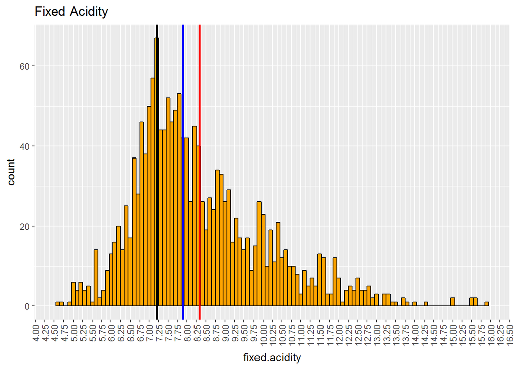

##### Summary

```
##    Min. 1st Qu.  Median    Mean 3rd Qu.    Max.
##    4.60    7.10    7.90    8.32    9.20   15.90
```

##### Mode

```
## [1] 7.2
```

The distribution of fixed acidity is right skewed and has some outliers. The majority of the fixed acidity falls in the range of 6.50 to 8.00.

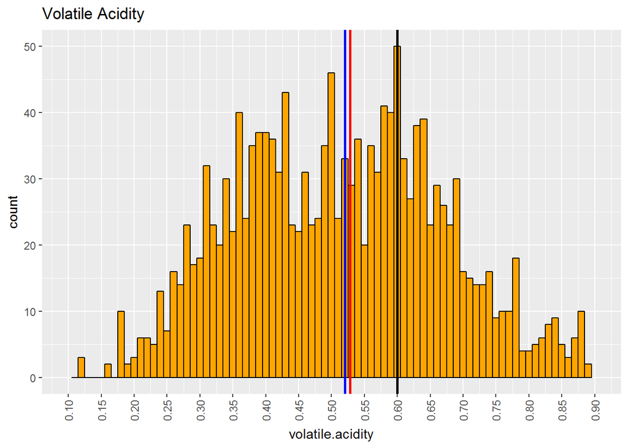

##### Summary

```
##    Min. 1st Qu.  Median    Mean 3rd Qu.    Max.
##  0.1200  0.3900  0.5200  0.5278  0.6400  1.5800
```

##### Mode

```
## [1] 0.6
```

Cutting out some outliers, the distribution for volatile.acidity has some peaks around .37 and around .58. What would be causing the different peaks in the data?

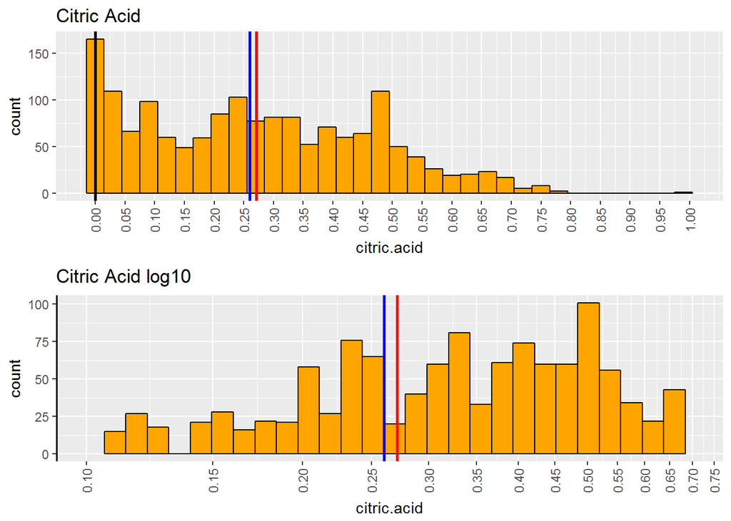

##### Summary

```
##    Min. 1st Qu.  Median    Mean 3rd Qu.    Max.
##   0.000   0.090   0.260   0.271   0.420   1.000
```

##### Mode

```
## [1] 0
```

Citric.acid levels peak at 0 and again at .49, with some other smaller peaks and one outlier at 1 and a mode 0. Median look to be somewhat close however I am not informed on how big a difference is in wine quality with a .011 change in citric.acid. I transformed the long tailed data and removed some outliers to get a better understanding of the citric acid amount. The majority of the citric acid levels fall in the range of .30 and .55.

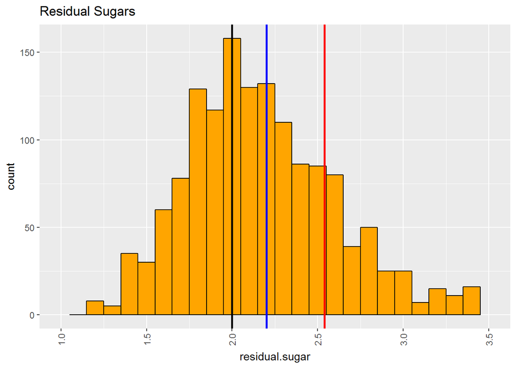

##### Summary

```
##    Min. 1st Qu.  Median    Mean 3rd Qu.    Max.
##   0.900   1.900   2.200   2.539   2.600  15.500
```

##### Mode

```
## [1] 2
```

Residual.sugar distribution looks norml with many outliers. Removing the outliers we see that the majority of residual sugar falls in the range of 1.8 to 2.3.

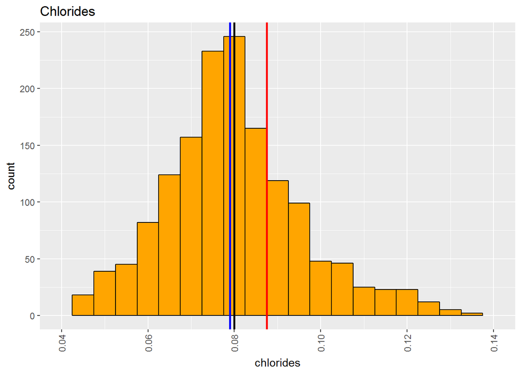

##### Summary

```
##    Min. 1st Qu.  Median    Mean 3rd Qu.    Max.
## 0.01200 0.07000 0.07900 0.08747 0.09000 0.61100
```

##### Mode

```
## [1] 0.08
```

After removing outliers we have a fairly normal distributions with most of the chlorides failing in the .07g to .09g range.

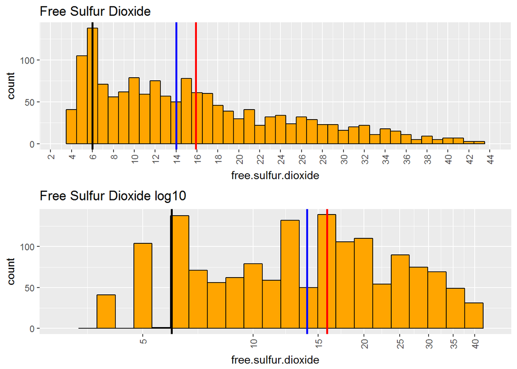

##### Summary

```
##    Min. 1st Qu.  Median    Mean 3rd Qu.    Max.
##    1.00    7.00   14.00   15.87   21.00   72.00
```

##### Mode

```
## [1] 6
```

Removing outliers and transforming the data, I can see that there are three peaks one at 6, one at 13 and one at 16.

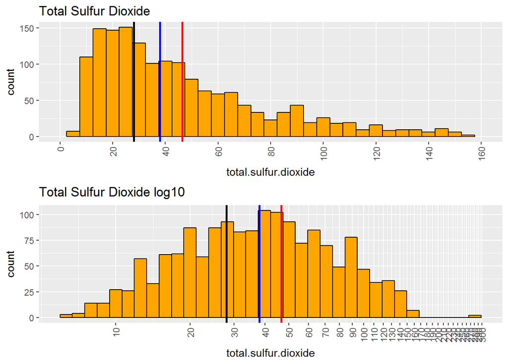

##### Summary

```
##    Min. 1st Qu.  Median    Mean 3rd Qu.    Max.
##    6.00   22.00   38.00   46.47   62.00  289.00
```

##### Mode

```
## [1] 28
```

Total sulfur dioxide is right skewed like free sulfur dioxide and has some outliers around 280 and 290. After transforming the data, the distribution is normal with a range of 25 to 55 for the most Sulfur Dioxide.

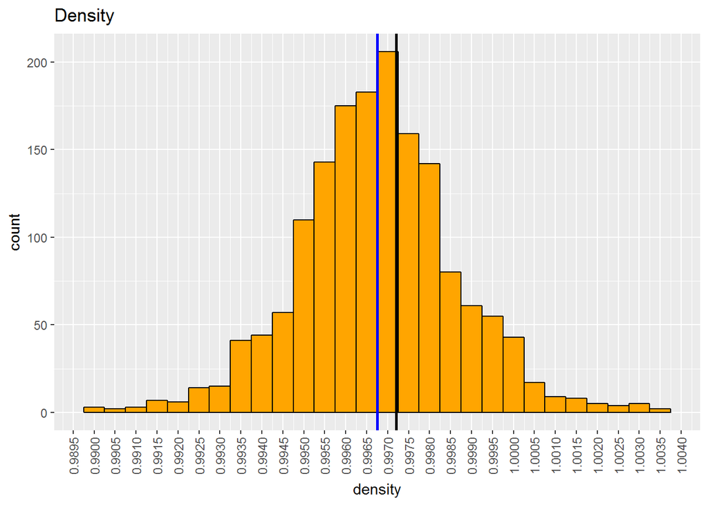

##### Summary

```
##    Min. 1st Qu.  Median    Mean 3rd Qu.    Max.
##  0.9901  0.9956  0.9968  0.9967  0.9978  1.0037
```

##### Mode

```
## [1] 0.9972
```

This looks normal, no outliers with the mojority fo density falling in the .9960 to .9980 range.

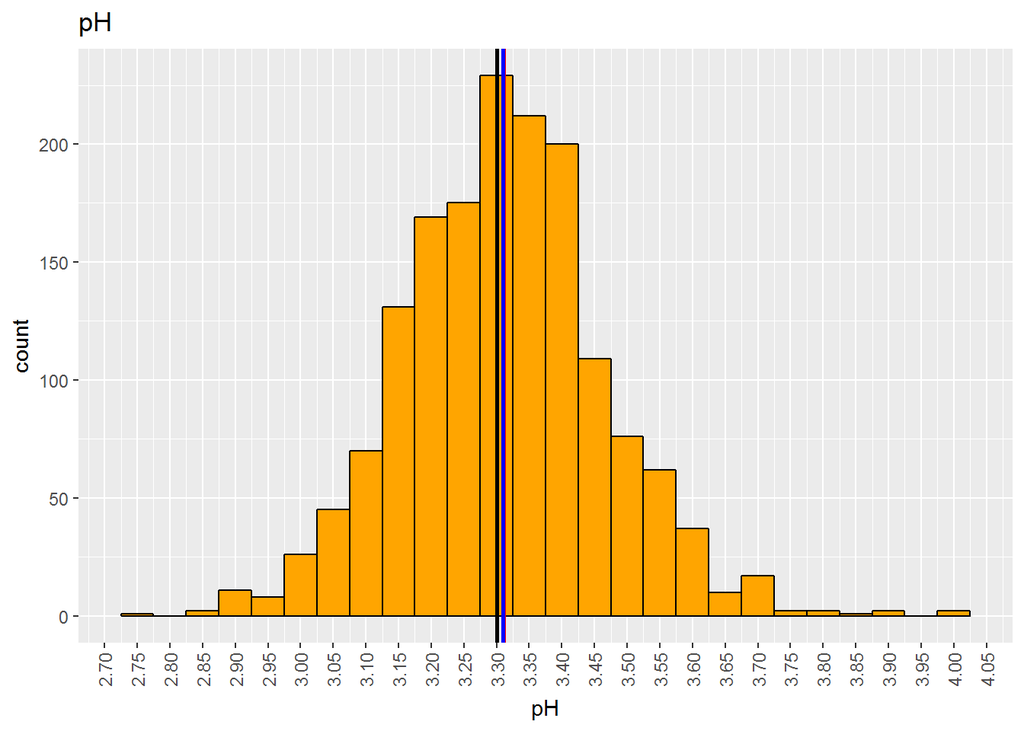

##### Summary

```
##    Min. 1st Qu.  Median    Mean 3rd Qu.    Max.
##   2.740   3.210   3.310   3.311   3.400   4.010
```

##### Mode

```
## [1] 3.3
```

This distribution looks normal as well with majority of pH levels in the 3.2 to 3.4 range.

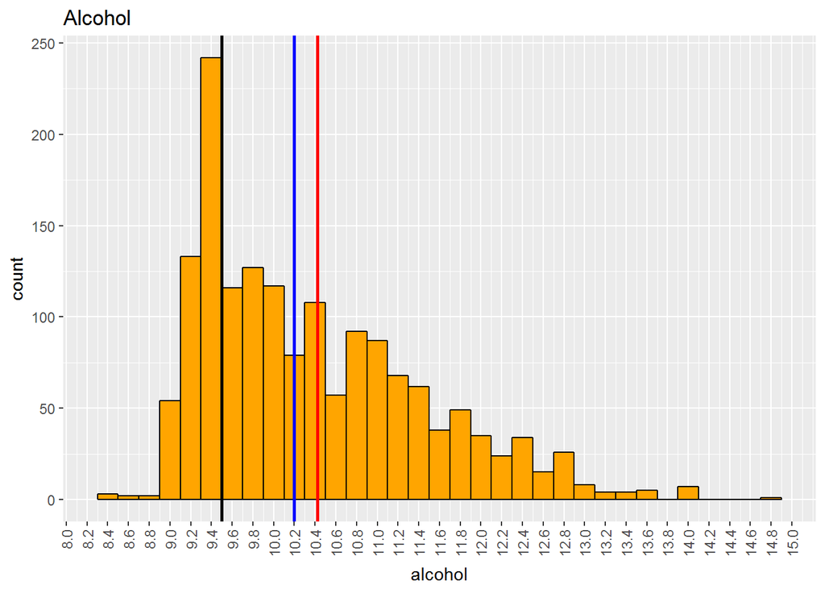

##### Summary

```
##    Min. 1st Qu.  Median    Mean 3rd Qu.    Max.
##    8.40    9.50   10.20   10.42   11.10   14.90
```

##### Mode

```
## [1] 9.5
```

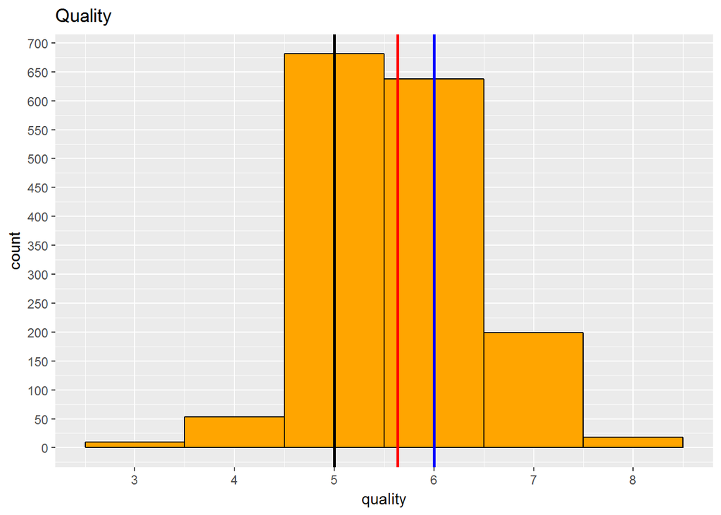

```r
ggplot(data = df_wine, aes(quality)) +
  geom_histogram(color='black',binwidth=1,fill='orange') +
  scale_x_continuous(breaks = seq(0,10,1)) +
  scale_y_continuous(breaks = seq(0,700,50)) +
  geom_vline(aes(xintercept = mean(df_wine$quality)),
             color='red', size=1) +
  geom_vline(aes(xintercept = median(df_wine$quality)),
             color='blue', size=1) +
  geom_vline(aes(xintercept = getmode(df_wine$quality)),
             color='black', size=1) +
  ggtitle('Quality ')
```

##### Counts by Quality

```
##
##   3   4   5   6   7   8
##  10  53 681 638 199  18
```

##### Summary

```
##    Min. 1st Qu.  Median    Mean 3rd Qu.    Max.
##   3.000   5.000   6.000   5.636   6.000   8.000
```

##### Mode

```
## [1] 5
```

Quality peaks at 5 and 6. most wines in this data set are average quality. I do not believe there is enough data to analyze the chemical make up of all wines with a quality rating of 8 and above or 3 and less.

# Univariate Analysis

### What is the structure of your dataset?

The dataset consists of 1,599 red wines with 11 variables that determine the quality of the wines from the red variants of the Portuguese “Vinho Verde” wine.

1 - fixed acidity: most acids involved with wine or fixed or nonvolatile (do not evaporate readily)

2 - volatile acidity: the amount of acetic acid in wine, which at too high of levels can lead to an unpleasant, vinegar taste

3 - citric acid: found in small quantities, citric acid can add ‘freshness’ and flavor to wines

4 - residual sugar: the amount of sugar remaining after fermentation stops, it’s rare to find wines with less than 1 gram/liter and wines with greater than 45 grams/liter are considered sweet

5 - chlorides: the amount of salt in the wine

6 - free sulfur dioxide: the free form of SO2 exists in equilibrium between molecular SO2 (as a dissolved gas) and bisulfite ion; it prevents microbial growth and the oxidation of wine

7 - total sulfur dioxide: amount of free and bound forms of S02; in low concentrations, SO2 is mostly undetectable in wine, but at free SO2 concentrations over 50 ppm, SO2 becomes evident in the nose and taste of wine

8 - density: the density of water is close to that of water depending on the percent alcohol and sugar content

9 - pH: describes how acidic or basic a wine is on a scale from 0 (very acidic) to 14 (very basic); most wines are between 3-4 on the pH scale

10 - sulphates: a wine additive which can contribute to sulfur dioxide gas (S02) levels, wich acts as an antimicrobial and antioxidant

11 - alcohol: the percent alcohol content of the wine

Output variable (based on sensory data): 12 - quality (score between 0 and 10)

### What is/are the main feature(s) of interest in your dataset?

The main feature is quality and how the other features enhance quality.

### What other features in the dataset do you think will help support your investigation into your feature(s) of interest?

I will look at the 11 features in order to try to determine correlation with wine quality.

### Did you create any new variables from existing variables in the dataset?

I did create a new feature/variable called quality_factor based on the quality feature.

### Of the features you investigated, were there any unusual distributions? Did you perform any operations on the data to tidy, adjust, or change the form of the data? If so, why did you do this?

I did run some transformation on some of the right skewed data distributions just to get a better understanding of the data. The Volatile Acidity seemed to appear bimodal, having a peak around .37 and around .58.

Quality ditribution pointed out the most wines fall in the average category from rating of 4 to 7, with little ratings in the poor 1 to 3 range and the best quality from 8 to 10.

### Quality Correlation Coefficients for each Feature

```
##                       [,1]
## fixed.acidity         0.12
## volatile.acidity     -0.39
## citric.acid           0.23
## residual.sugar        0.01
## chlorides            -0.13
## free.sulfur.dioxide  -0.05
## total.sulfur.dioxide -0.19
## density              -0.17
## pH                   -0.06
## sulphates             0.25
## alcohol               0.48
## quality               1.00
```

The top three features that correlation with quality seems to come from alcohol, volatile acidity and sulphates. These correlation are moderate at best. This seems to suggest that we may be missing some features that better correlate with quality but lets continue on.

### Feature Selection

```
## lm variable importance
##
##                      Overall
## alcohol              10.4290
## volatile.acidity      8.9478
## sulphates             8.0143
## total.sulfur.dioxide  4.4798
## chlorides             4.4701
## pH                    2.1590
## free.sulfur.dioxide   2.0086
## citric.acid           1.2404
## residual.sugar        1.0886
## fixed.acidity         0.9631
## density               0.8266
```

### Feature Selection Plot

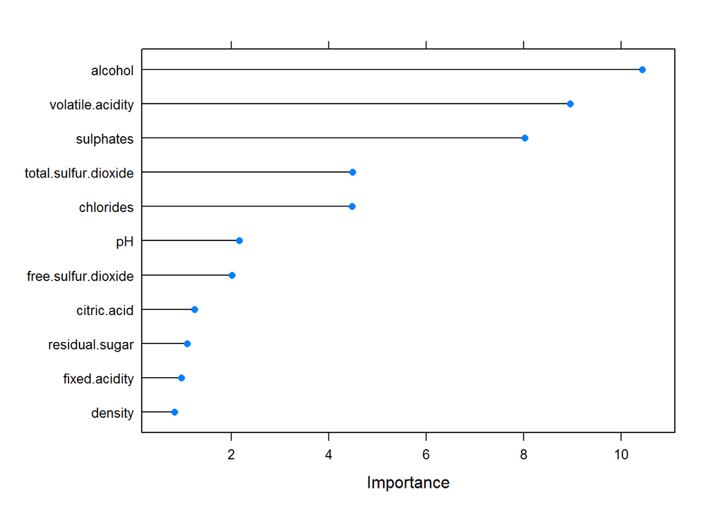

The feature selection model also suggest the three top features with the highest correlation with quality is Volatile acidity, alcohol, sulphates.

### Correlation Coefficent Matrix

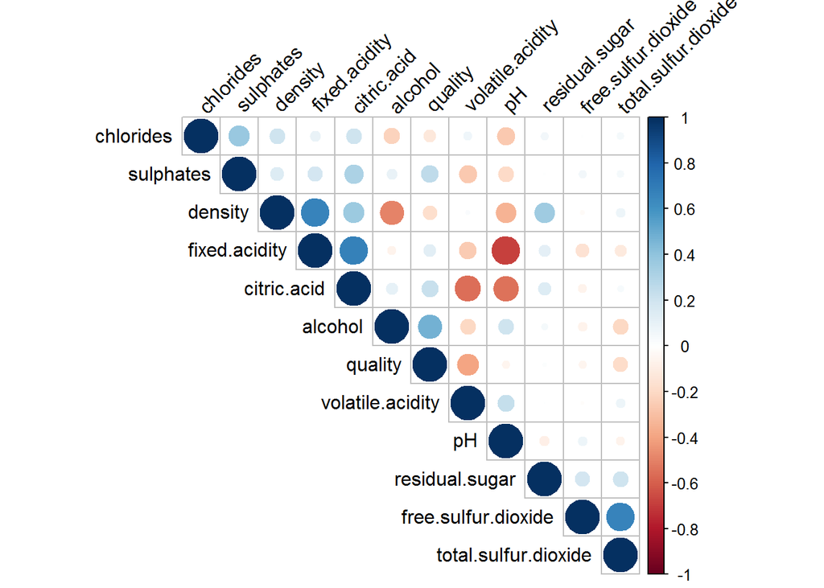

This plot again suggests that alcohol, volatile acidity and sulphates are the the features with the most correlation.

There is one interesting observation with this matrix, it most cases acidity and pH are on seperate ends of the scale as the case with fixed acidity and citric acid. However, pH and volatile acidity have positive correlation.

# Bivariate Plots Section

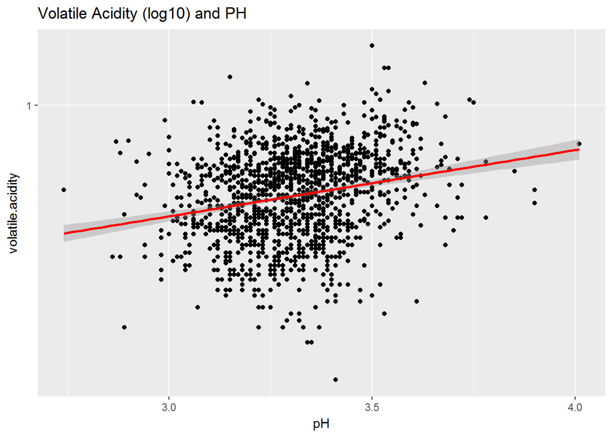

There does appear to be a poistive correlation between pH and volatile acidity. I will look at this some more later in the mulivariate plot section to see what effect this may have on quality.

I wanted to see the visualiztion of all the features on quality keeping in mind that the top three features are Alcohol, Sulphates and Volatile Acidity.

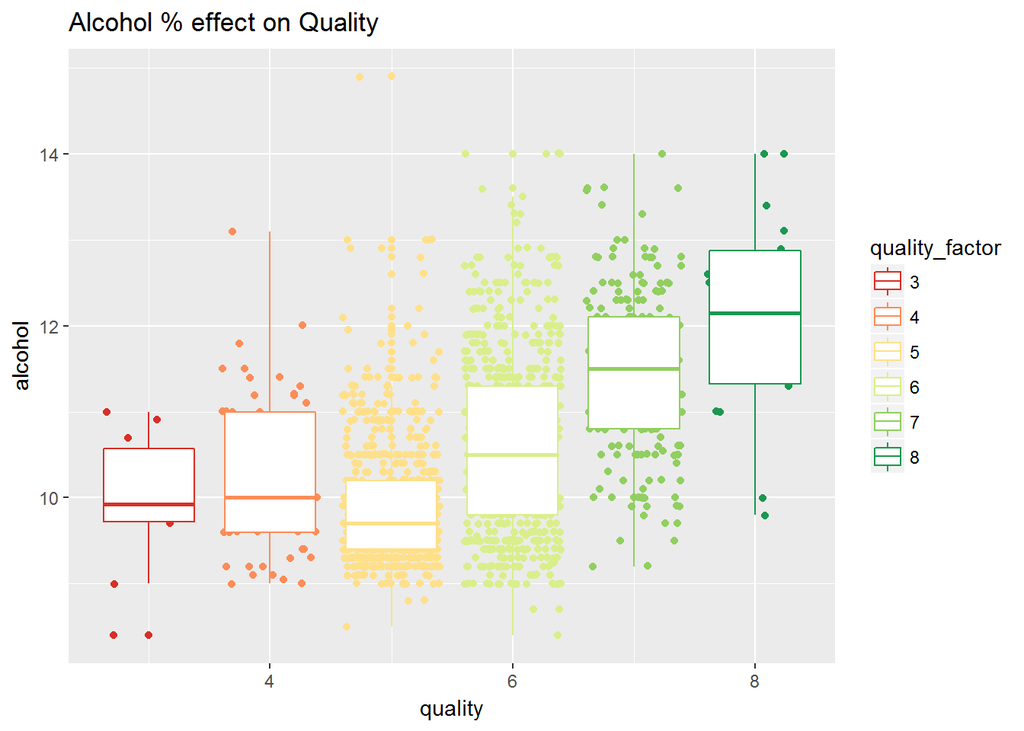

There does seem to be a small correlation between alchohol levels and quality of wine as the alcohol level increases the quality of the wine makes slight increase.

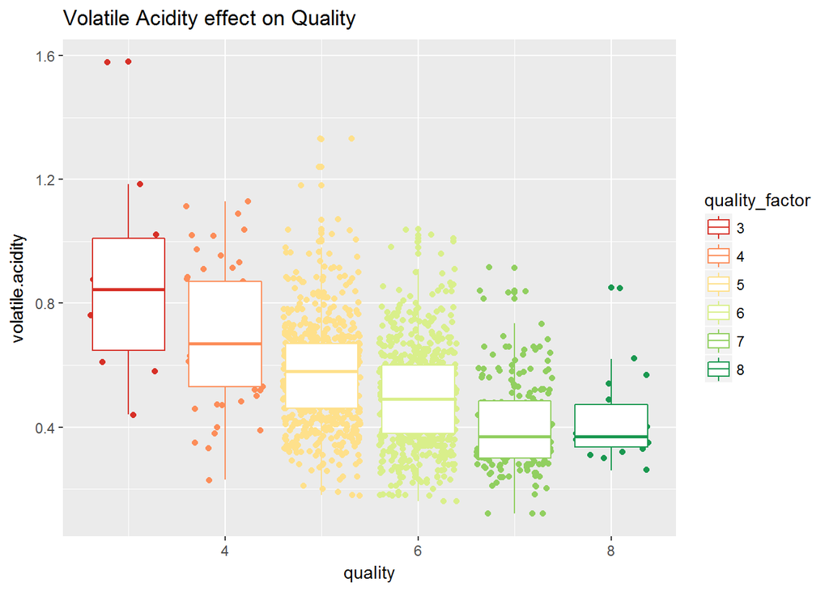

Here there is a negative correlation in that the quality decreases as violatile acidity increases.

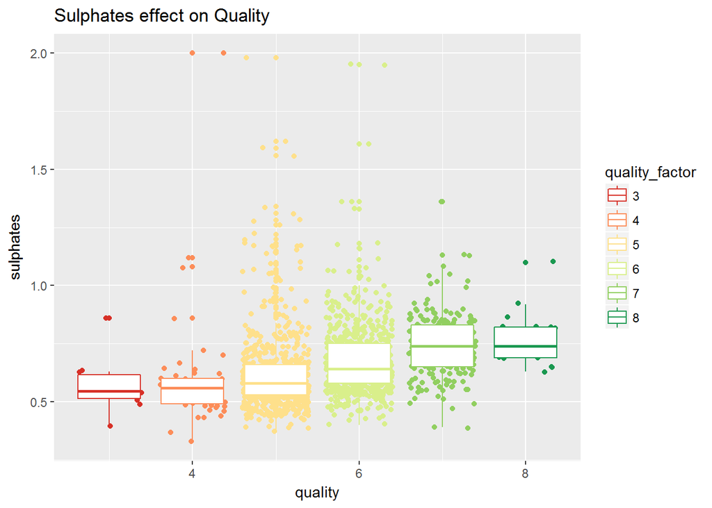

Suphates also look to have a very small positive correlation with quality in that as sulphates increase quality increses.

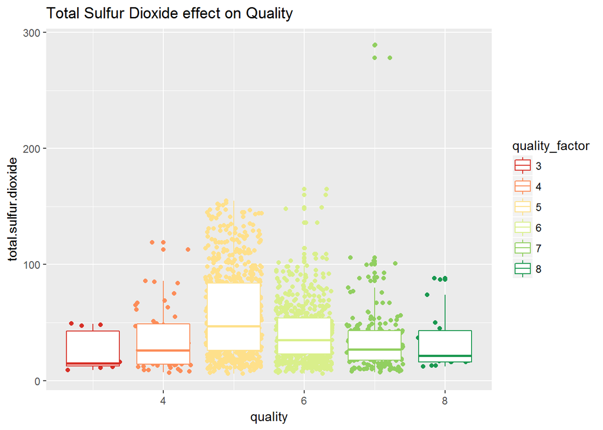

Total Sulfur Dioxide does not seem to have any correlation with quality.

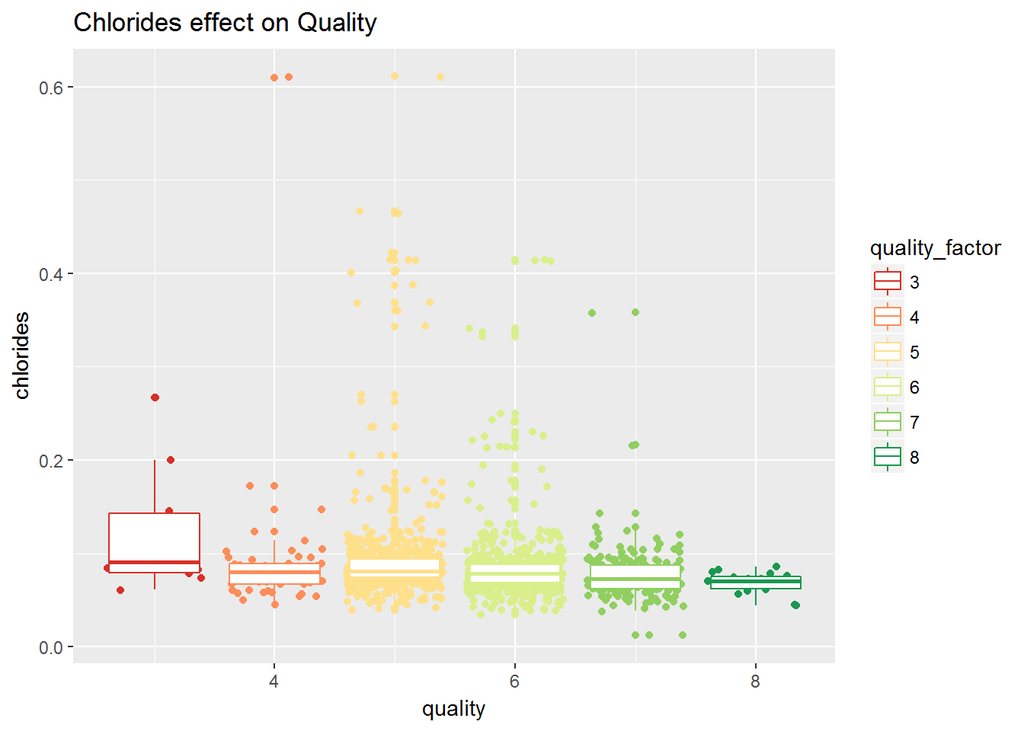

It does not seem to be a correlation between chlorides and quality. As the lower quality wines seem to have the same amount of chlorides as the more quality wines.

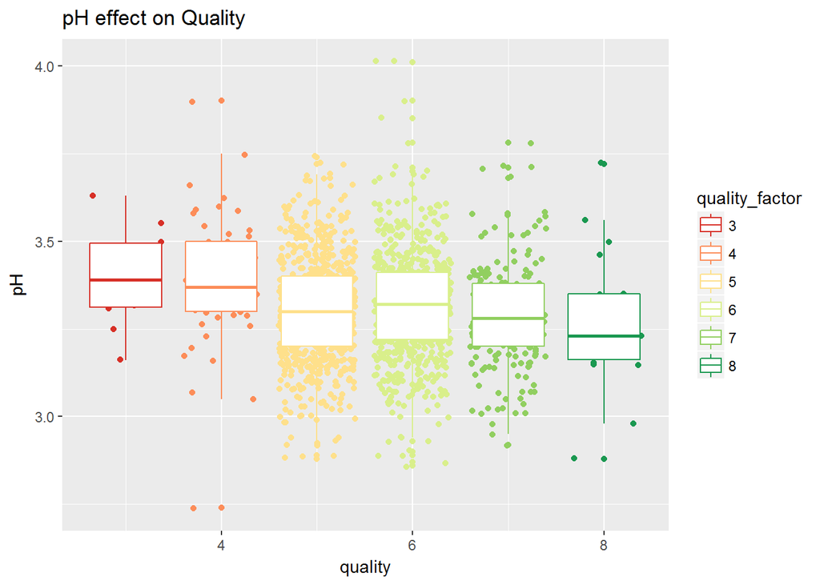

pH level averages are a little lower as the quality increases. However, since the pH levels seem to cross levels for each level, it does not seem to indicate a correlation between pH and quality.

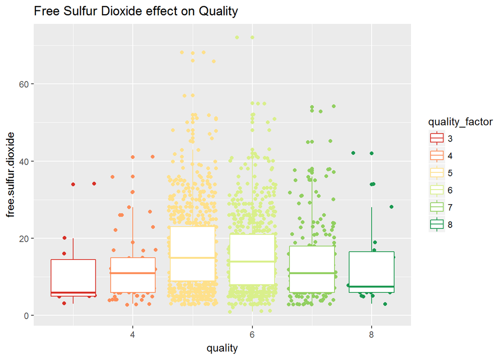

Free sulfur dioxide has no correlation with quality.

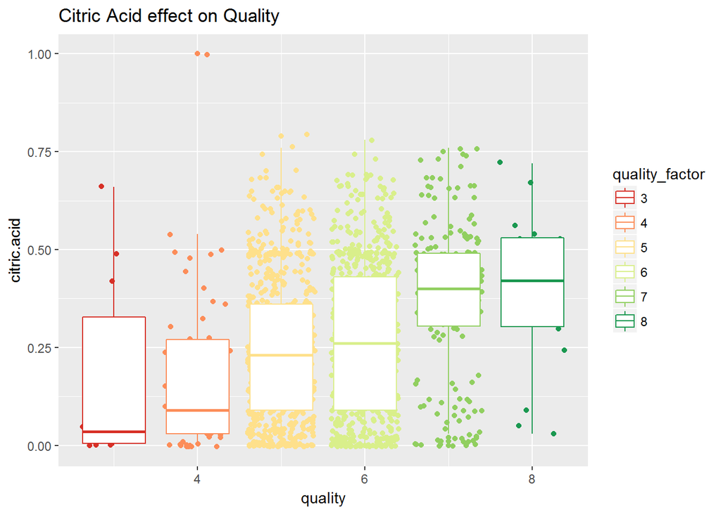

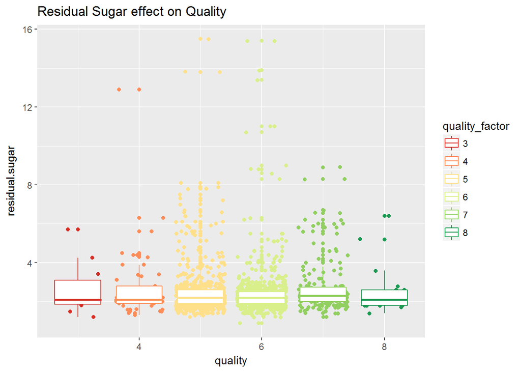

Residual sugars amounts do not seem to effect quality one way or another.

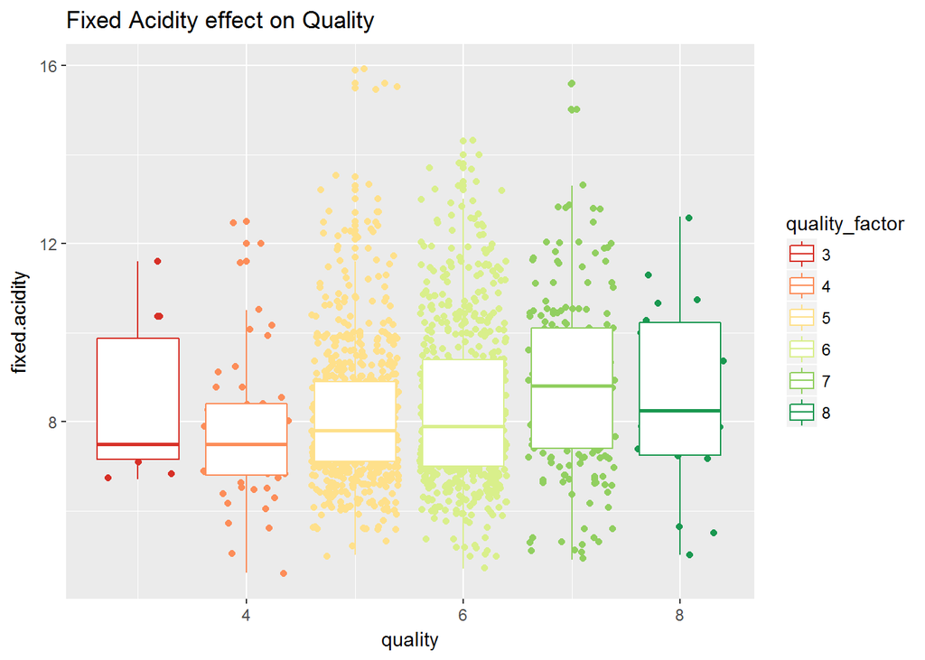

There does not seem to be a correlation between fixed acidity and quality as well.

[figure not shown]

Density does seem to have a low correlation in that as density increases quality decreases

# Bivariate Analysis

### Talk about some of the relationships you observed in this part of the investigation. How did the feature(s) of interest vary with other features in the dataset?

Not one feature by itself has a strong correlation with quality. Although we did see some features with small to moderate relationships with quality, I failed to accept that one feature alone would increase the quality of the wine.

BAsed on the coefficient correlation matrix, there were moderate relationships between the following features, there may be a combination of these features that will enhance the quality of wines. I will look at these next.

ph and fixed acidity ph and citric acid density and fixed acidity fixed acidity and citric acid free sulfur dioxide and total sulfur dioxide density and alcohol volatile acidity and citric acid alcohol and volatile acidity

### Did you observe any interesting relationships between the other features (not the main feature(s) of interest)?

Volitale Acidity and pH has a poistivie correlation, which may suggest there is another feature that changes this correlation.

### What was the strongest relationship you found?

The strongest relationship was between PH and fixed acidity at -.68. Which would make sense as acidity increases pH will decrease and vice versa.

# Multivariate Plots Section

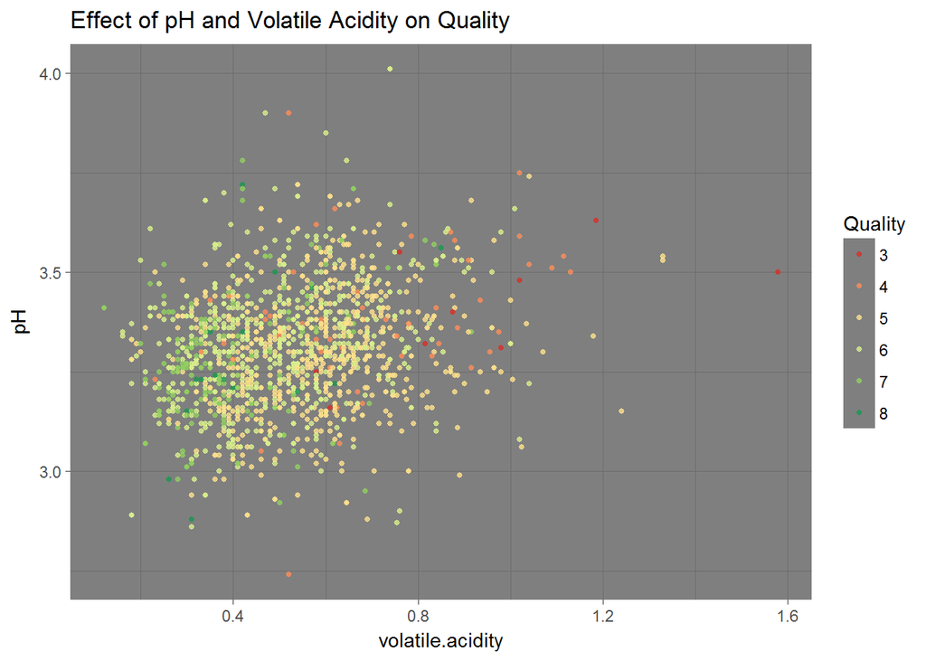

Earlier we saw a small positive correlation between pH and volatile acidity and here I do not see that this correlation has any effect on quality of wine.

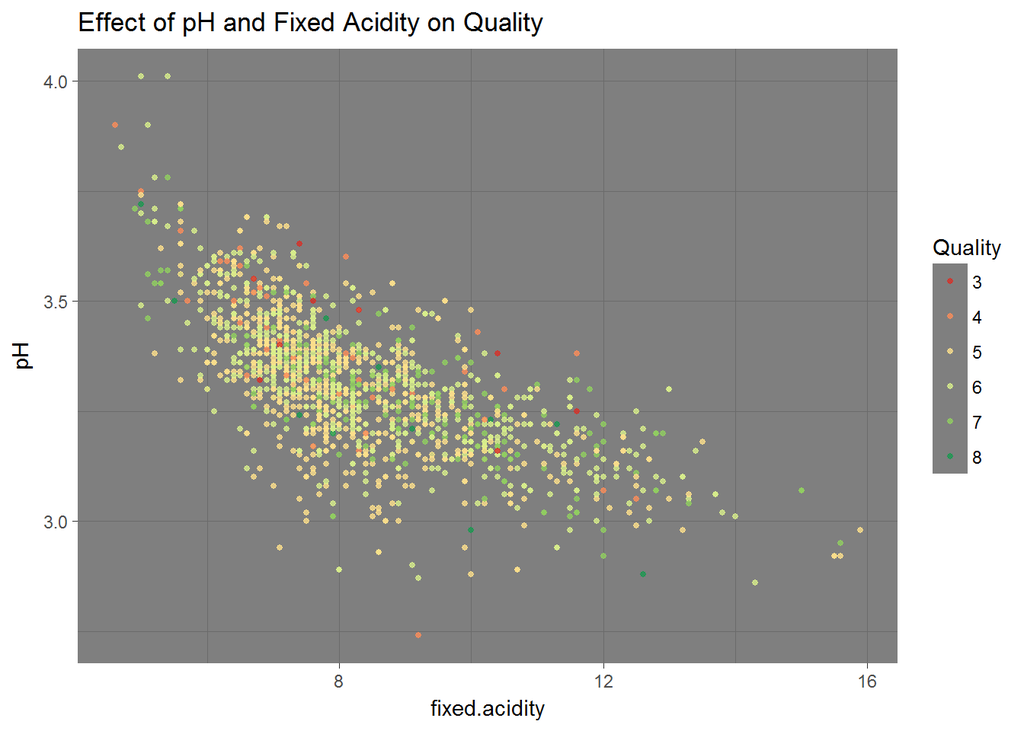

Not seeing any correlation with Quality even though there is a negative correlation with pH and fixed acidity.

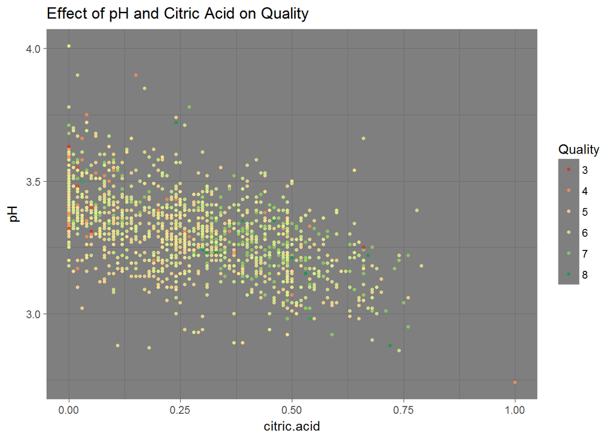

Not seeing any correlation with quality and the negative relations ship with pH and citric acid.

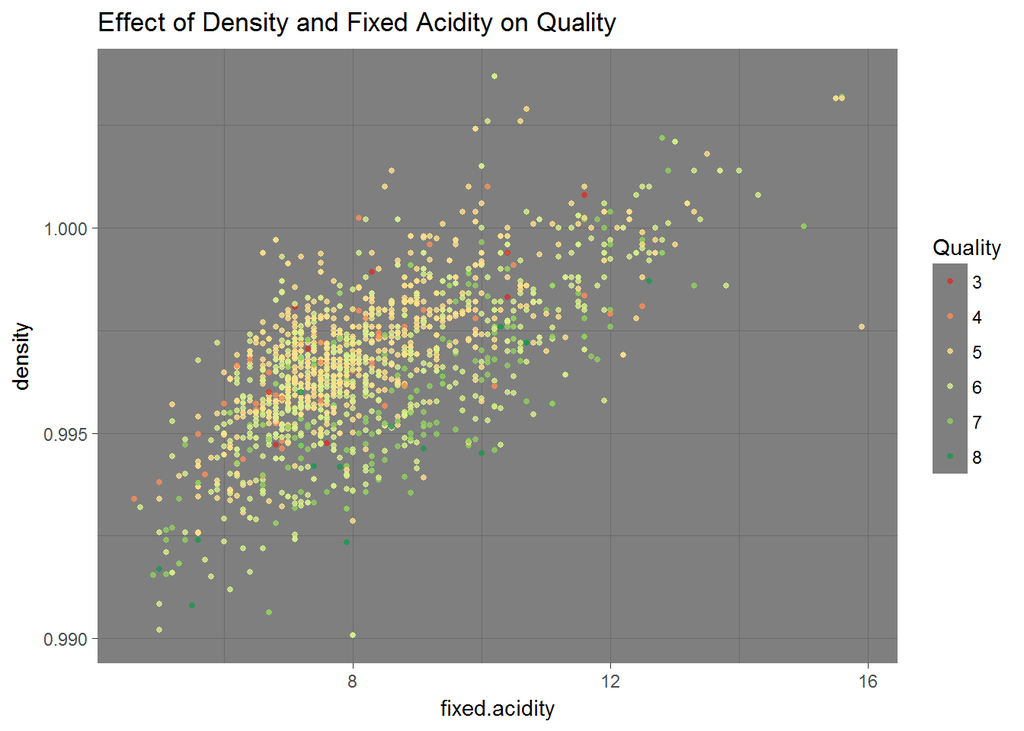

No correlation with Quality with the positive correlation between density and fixed acidity.

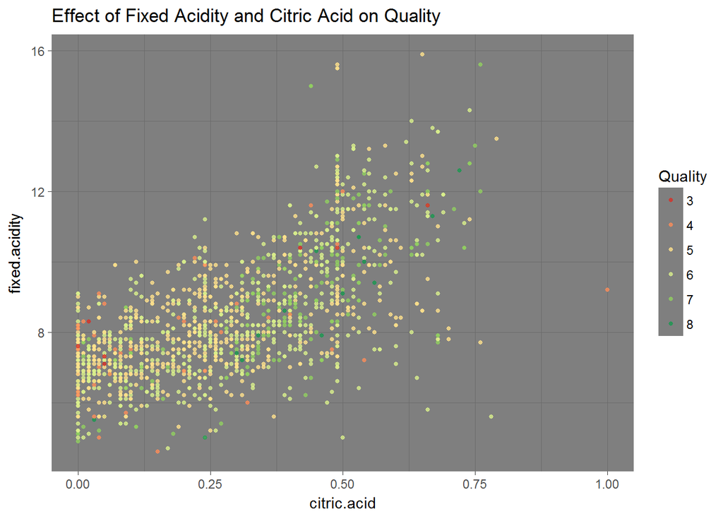

No correlation with quality given the positive correlation between fixed acidity and citric acid.